# Three (Groups of) Blind Mice

Familial Clusters of Cataract Development in Irradiated Mice

Familial Clusters of Cataract Development in Irradiated Mice

Alyssa Allsop and Amira Burns

2022-06-21

## Introduction

Little is known about the effects of high atomic number and energy (HZE) radiation, a main component of space radiation to which exposure is unavoidable beyond Earth’s magnetic field. In contrast, extensive research shows exposure to high doses of gamma radiation leads to acute radiation sickness. Effects include damage to the blood forming system, GI system, immune system, increased risk for cancer, cardiovascular disease, neurodegenerative disease, death, and cataracts.. The serious health implications from HZE radiation for astronauts who leave Earth’s magnetic field warrant further study. Adverse effects from radiation may also be attributable to other factors, including genetics; several different cancers have been observed to cluster in mice families (Chernyavskiy, et. al., 2017). Accounting for potential family clustering allows for thorough examination of the primary research questions. Is there a genetic susceptibility to cataracts caused by radiation? Accounting for potential genetic susceptibility, is there a difference in cataract presentation between HZE radiation and gamma radiation? The full dataset includes 1820 unique mice from 48 unique families, with equal random assignments by family to each of three treatment groups. Mice are bred over several generations to create a genetically heterogeneous sample, the better to represent the diverse biology of the human population. The treatments are HZE irradiation, gamma irradiation, and non-irradiated control. The HZE group is irradiated with either silicon or iron nuclei HZE ions, which are considered as a single treatment group. The second group is subjected to 137 Cs gamma irradiation. Mice in both irradiated groups are exposed to radiation at 7-12 weeks of age. The third group is unirradiated control. All mice are monitored until 800 days of age –effectively a survival study. Mice are checked weekly for symptoms of cataracts, cataract risk factors, and other symptoms of radiation exposure such as tumors and carcinomas. Resources do not allow for weekly measurement of every mouse; previous measurements are carried forward if a mouse is not assessed on a particular week. This analysis uses a simplified version of the data set - a snapshot of the 1169 mice that are alive at 552 days. This cutoff is chosen because it is the median survival time for the group with the shortest median survival. There are 47 unique families with n = 396 in the HZE group, n = 277 in the gamma radiation group, and n = 496 in the unirradiated control group. There are up to two generations of mice pups from each family in the dataset, but generation is not distinguished in the simplified data. Family size ranges from n = 11 to n = 48, with median family size of 24.

## 0.2 Introduction

Little is known about the effects of high atomic number and energy (HZE) radiation, a main component of space radiation to which exposure is unavoidable beyond Earth’s magnetic field. In contrast, extensive research shows exposure to high doses of gamma radiation leads to acute radiation sickness. Effects include damage to the blood forming system, GI system, immune system, increased risk for cancer, cardiovascular disease, neurodegenerative disease, death, and cataracts.. The serious health implications from HZE radiation for astronauts who leave Earth’s magnetic field warrant further study. Adverse effects from radiation may also be attributable to other factors, including genetics; several different cancers have been observed to cluster in mice families (Chernyavskiy, et. al., 2017). Accounting for potential family clustering allows for thorough examination of the primary research questions. Is there a genetic susceptibility to cataracts caused by radiation? Accounting for potential genetic susceptibility, is there a difference in cataract presentation between HZE radiation and gamma radiation? The full dataset includes 1820 unique mice from 48 unique families, with equal random assignments by family to each of three treatment groups. Mice are bred over several generations to create a genetically heterogeneous sample, the better to represent the diverse biology of the human population. The treatments are HZE irradiation, gamma irradiation, and non-irradiated control. The HZE group is irradiated with either silicon or iron nuclei HZE ions, which are considered as a single treatment group. The second group is subjected to 137 Cs gamma irradiation. Mice in both irradiated groups are exposed to radiation at 7-12 weeks of age. The third group is unirradiated control. All mice are monitored until 800 days of age –effectively a survival study. Mice are checked weekly for symptoms of cataracts, cataract risk factors, and other symptoms of radiation exposure such as tumors and carcinomas. Resources do not allow for weekly measurement of every mouse; previous measurements are carried forward if a mouse is not assessed on a particular week. This analysis uses a simplified version of the data set - a snapshot of the 1169 mice that are alive at 552 days. This cutoff is chosen because it is the median survival time for the group with the shortest median survival. There are 47 unique families with n = 396 in the HZE group, n = 277 in the gamma radiation group, and n = 496 in the unirradiated control group. There are up to two generations of mice pups from each family in the dataset, but generation is not distinguished in the simplified data. Family size ranges from n = 11 to n = 48, with median family size of 24.

| Treatment | Cataract Score 1 | Cataract Score 2 | Cataract Score 3 | Cataract Score 4 | Total |
| --- | --- | --- | --- | --- | --- |
| Unirradiated | 438 | 45 | 11 | 2 | 496 |
| Gamma | 214 | 53 | 6 | 4 | 277 |
| HZE | 281 | 107 | 6 | 2 | 396 |

The response is Merriam-Focht cataract score (Merriam & Focht, 1957), an ordinal categorical variable corresponding to radiation-associated ocular changes in the eye. A score of 0 is associated with a completely clear lens, while a score of 5 is associated with a completely occluded lens. This dataset contains cataract score levels = [1, 2, 3, 4]. A score $\ge$ 2 indicates presence of cataracts, and the small sample sizes for score $>$ 2 across all treatment groups raise concerns about making inference on an ordinal analysis; consequently, the response is converted to binary *Cataracts* with score = 1 converted to 0, and score $\ge$ 2 converted to 1. The main experimental factor is *Treatment*, a categorical variable with three levels = [HZE radiation, gamma radiation, non-irradiated control]. A single random effect, genetic *Family*, is a categorical factor with 47 levels. Both Treatment and Family are central to the experimental design and will serve as the basis for all models considered. Additional covariates under consideration are:  
+ Sex: categorical with two levels = [Male, Female].  
+ Weight: numeric, in grams; range = [16.11, 59.85].  
+ Coat color: categorical with six levels = [albino, black, creme brown, grey, light brown, light grey].  
+ Body condition score (BCS): ordered categorical with 5 levels, representing a range from emaciated to obese. Levels = [BC1, BC2, BC3, BC4, BC5].  
+ Age: numeric, in days; range = [552, 816].  
+ Three categorical variables indicating presence of other cancers: Harderian Tumor: categorical with three levels = [bilateral, unilateral, none]. Myeloid Leukemia: binary categorical with two levels = [0, 1]. PreT Lymphoma: binary categorical with two levels = [0, 1].

The experimental design prescribed the inclusion of Treatment and Family in a final model.

## Summary Statistics

Exploratory data analysis consisted of investigating the response in terms of Treatment and Family and any potential associations between the response and covariates. In addition, possible interactions and correlations between covariates and the primary predictors in terms of the response were of interest.

The response is Merriam-Focht cataract score (Merriam & Focht, 1957), an ordinal categorical variable corresponding to radiation-associated ocular changes in the eye. A score of 0 is associated with a completely clear lens, while a score of 5 is associated with a completely occluded lens. This dataset contains cataract score levels = [1, 2, 3, 4]. A score $\ge$ 2 indicates presence of cataracts, and the small sample sizes for score $>$ 2 across all treatment groups raise concerns about making inference on an ordinal analysis; consequently, the response is converted to binary *Cataracts* with score = 1 converted to 0, and score $\ge$ 2 converted to 1. The main experimental factor is *Treatment*, a categorical variable with three levels = [HZE radiation, gamma radiation, non-irradiated control]. A single random effect, genetic *Family*, is a categorical factor with 47 levels. Both Treatment and Family are central to the experimental design and will serve as the basis for all models considered. Additional covariates under consideration are:  
+ Sex: categorical with two levels = [Male, Female].  
+ Weight: numeric, in grams; range = [16.11, 59.85].  
+ Coat color: categorical with six levels = [albino, black, creme brown, grey, light brown, light grey].  
+ Body condition score (BCS): ordered categorical with 5 levels, representing a range from emaciated to obese. Levels = [BC1, BC2, BC3, BC4, BC5].  
+ Age: numeric, in days; range = [552, 816].  
+ Three categorical variables indicating presence of other cancers: Harderian Tumor: categorical with three levels = [bilateral, unilateral, none]. Myeloid Leukemia: binary categorical with two levels = [0, 1]. PreT Lymphoma: binary categorical with two levels = [0, 1].

The experimental design prescribed the inclusion of Treatment and Family in a final model.

## 0.3 Summary Statistics

Exploratory data analysis consisted of investigating the response in terms of Treatment and Family and any potential associations between the response and covariates. In addition, possible interactions and correlations between covariates and the primary predictors in terms of the response were of interest.

| Treatment | Cataracts | Female n | Female prop | Male n | Male prop | $\sum$ n | $\sum$ prop |
| --- | --- | --- | --- | --- | --- | --- | --- |
| **Control** |  |  |  |  |  |  |  |
|  | No | 238 | 0.92 | 200 | 0.84 | 438 | 0.88 |
|  | Yes | 20 | 0.08 | 38 | 0.16 | 58 | 0.12 |
|  | $\sum$ | 258 |  | 238 |  | 496 |  |
| **Gamma** |  |  |  |  |  |  |  |
|  | No | 131 | 0.90 | 83 | 0.63 | 214 | 0.77 |
|  | Yes | 14 | 0.10 | 49 | 0.37 | 63 | 0.23 |
|  | $\sum$ | 145 |  | 132 |  | 277 |  |
| **HZE** |  |  |  |  |  |  |  |
|  | No | 181 | 0.88 | 100 | 0.52 | 281 | 0.71 |
|  | Yes | 24 | 0.12 | 91 | 0.48 | 115 | 0.29 |
|  | $\sum$ | 205 |  | 191 |  | 396 |  |
| **$\sum$** |  |  |  |  |  |  |  |
|  | $\sum$ | 608 |  | 561 |  | 1169 |  |

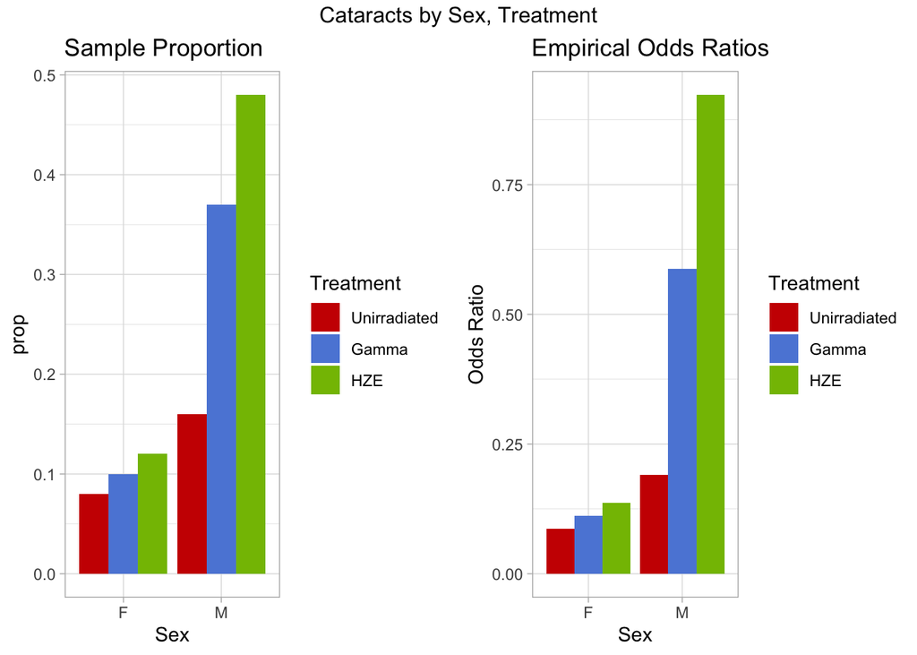

## Statistical Methods

### Frequentist Approach

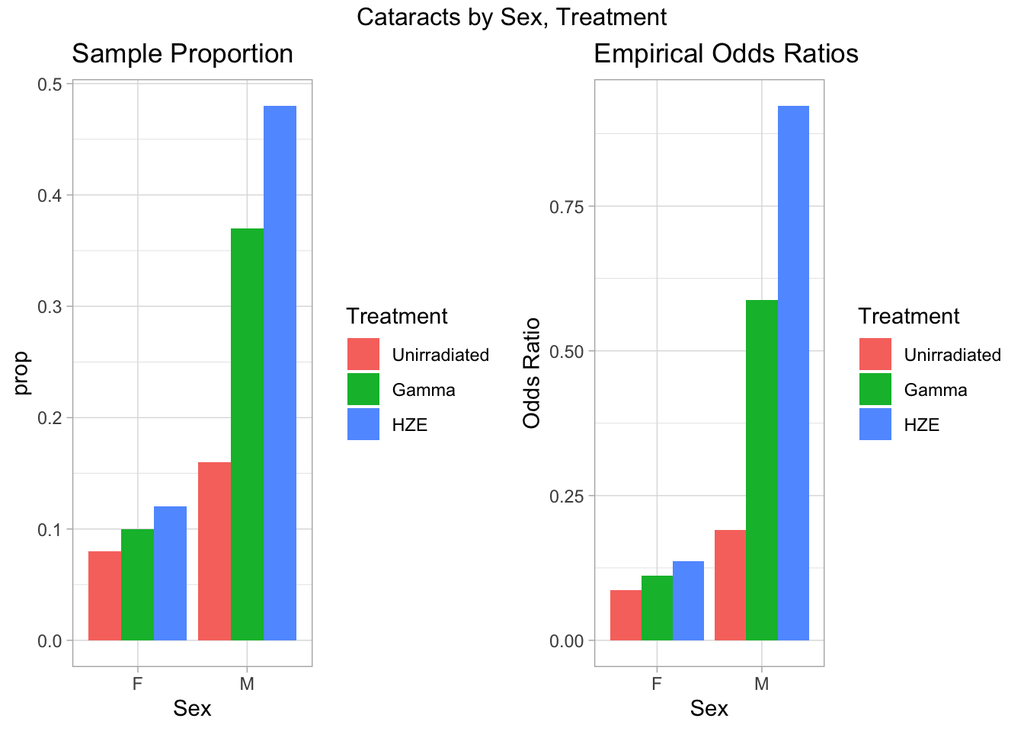

## 0.4 Statistical Methods

### 0.4.1 Frequentist Approach

```
## Generalized linear mixed model fit by maximum likelihood (Laplace
##   Approximation) [glmerMod]
##  Family: binomial  ( logit )
## Formula: Cataracts ~ Treatment * Sex + (1 | Family)
##    Data: cats
##
##      AIC      BIC   logLik deviance df.resid
##   1018.0   1053.4   -502.0   1004.0     1162
##
## Scaled residuals:
##     Min      1Q  Median      3Q     Max
## -1.9388 -0.4201 -0.3050 -0.2193  4.7063
##
## Random effects:
##  Groups Name        Variance Std.Dev.
##  Family (Intercept) 0.3949   0.6284
## Number of obs: 1169, groups:  Family, 47
##
## Fixed effects:
##                     Estimate Std. Error z value Pr(>|z|)
## (Intercept)          -2.6973     0.2608 -10.343  < 2e-16 ***
## TreatmentGamma        0.2137     0.3705   0.577  0.56409
## TreatmentHZE          0.5007     0.3239   1.546  0.12214
## SexM                  0.8875     0.2981   2.977  0.00291 **
## TreatmentGamma:SexM   0.9748     0.4548   2.144  0.03207 *
## TreatmentHZE:SexM     1.2068     0.4020   3.002  0.00269 **
## ---
## Signif. codes:  0 '***' 0.001 '**' 0.01 '*' 0.05 '.' 0.1 ' ' 1
##
## Correlation of Fixed Effects:
##             (Intr) TrtmnG TrtHZE SexM   TrG:SM
## TreatmntGmm -0.571
## TreatmntHZE -0.666  0.464
## SexM        -0.730  0.501  0.578
## TrtmntGm:SM  0.455 -0.815 -0.375 -0.648
## TrtmnHZE:SM  0.513 -0.373 -0.800 -0.733  0.487
```

### 0.4.2 Bayesian Approach

With non-informative parameters:
$$\begin{aligned}
\beta_0 &\sim N(0, 0.001)\\
\beta_1 &\sim N(0, 0.001)\\
\beta_2 &\sim N(0, 0.001)\\
\beta_3 &\sim N(0, 0.001)\\
\beta_4 &\sim N(0, 0.001)\\
\beta_5 &\sim N(0, 0.001)\\
v_i &\sim N(0, \sigma^2)\\
\tau &\sim Gamma(0.001, 0.001) \mbox{ where}\ \sigma^2 = 1/\tau\\
\end{aligned}$$

The model was run through a Gibbs sampler Markov Chain Monte Carlo (MCMC) algorithm to approximate the posterior distribution of all fixed effects estimates and the variance of the random effect. 3 chains of 60000 total iterations with a 10000-iteration burn-in period; starting values were obtained from the estimates generated by the Frequentist model, with noise added to avoid false convergence.

The model was run through a Gibbs sampler Markov Chain Monte Carlo (MCMC) algorithm to approximate the posterior distribution of all fixed effects estimates and the variance of the random effect. 3 chains of 60000 total iterations with a 10000-iteration burn-in period; starting values were obtained from the estimates generated by the Frequentist model, with noise added to avoid false convergence.

|  | GLMM Est | MCMC Mean | MCMC Median | MCMC Mode | MCMC SD | HPD Lower | HPD Upper |
| --- | --- | --- | --- | --- | --- | --- | --- |
| $\beta_0$ | 0.063 | 0.063 | 0.062 | 0.057 | 0.016 | 0.034 | 0.094 |
| $\beta_1$ | 0.553 | 0.549 | 0.551 | 0.550 | 0.090 | 0.371 | 0.720 |
| $\beta_2$ | 0.623 | 0.621 | 0.624 | 0.634 | 0.076 | 0.469 | 0.764 |
| $\beta_3$ | 0.708 | 0.708 | 0.710 | 0.714 | 0.062 | 0.589 | 0.828 |
| $\beta_4$ | 0.726 | 0.721 | 0.729 | 0.723 | 0.090 | 0.544 | 0.883 |
| $\beta_5$ | 0.770 | 0.763 | 0.771 | 0.776 | 0.072 | 0.618 | 0.892 |
| $\sigma^2$ | 0.597 | 0.609 | 0.604 | 0.585 | 0.041 | 0.539 | 0.694 |

[figure not shown]

## Limitations and Alternatives

Presence of competing risks in the experimental design obscure the presence of family clusters of cataracts. It is reasonable to assume that individuals in the irradiated Treatment groups were more likely to die due to more acute effects of irradiation before developing cataracts, compared to individuals in the control group. Simplifying the dataset by instituting a cutoff age attempts to address this limitation, but the issue persists even after excluding individuals deceased before Age = 552.

## 0.5 Limitations and Alternatives

Presence of competing risks in the experimental design obscure the presence of family clusters of cataracts. It is reasonable to assume that individuals in the irradiated Treatment groups were more likely to die due to more acute effects of irradiation before developing cataracts, compared to individuals in the control group. Simplifying the dataset by instituting a cutoff age attempts to address this limitation, but the issue persists even after excluding individuals deceased before Age = 552.

## 0.6 Results and Conclusions

```
## Sex = F:
##  Treatment      prob     SE  df asymp.LCL asymp.UCL null z.ratio p.value
##  Unirradiated 0.0631 0.0154 Inf    0.0389     0.101  0.5 -10.343  <.0001
##  Gamma        0.0770 0.0219 Inf    0.0436     0.132  0.5  -8.062  <.0001
##  HZE          0.1001 0.0221 Inf    0.0643     0.153  0.5  -8.942  <.0001
##
## Sex = M:
##  Treatment      prob     SE  df asymp.LCL asymp.UCL null z.ratio p.value
##  Unirradiated 0.1407 0.0252 Inf    0.0982     0.198  0.5  -8.697  <.0001
##  Gamma        0.3495 0.0485 Inf    0.2613     0.449  0.5  -2.913  0.0036
##  HZE          0.4744 0.0448 Inf    0.3882     0.562  0.5  -0.569  0.5693
##
## Confidence level used: 0.95
## Intervals are back-transformed from the logit scale
## Tests are performed on the logit scale
```

```
## Sex = F:
##  contrast             odds.ratio    SE  df null z.ratio p.value
##  Gamma / Unirradiated       1.24 0.459 Inf    1   0.577  0.8325
##  HZE / Unirradiated         1.65 0.534 Inf    1   1.546  0.2695
##  HZE / Gamma                1.33 0.482 Inf    1   0.793  0.7071
##
## Sex = M:
##  contrast             odds.ratio    SE  df null z.ratio p.value
##  Gamma / Unirradiated       3.28 0.865 Inf    1   4.509  <.0001
##  HZE / Unirradiated         5.51 1.331 Inf    1   7.076  <.0001
##  HZE / Gamma                1.68 0.412 Inf    1   2.115  0.0868
##
## P value adjustment: tukey method for comparing a family of 3 estimates
## Tests are performed on the log odds ratio scale
```

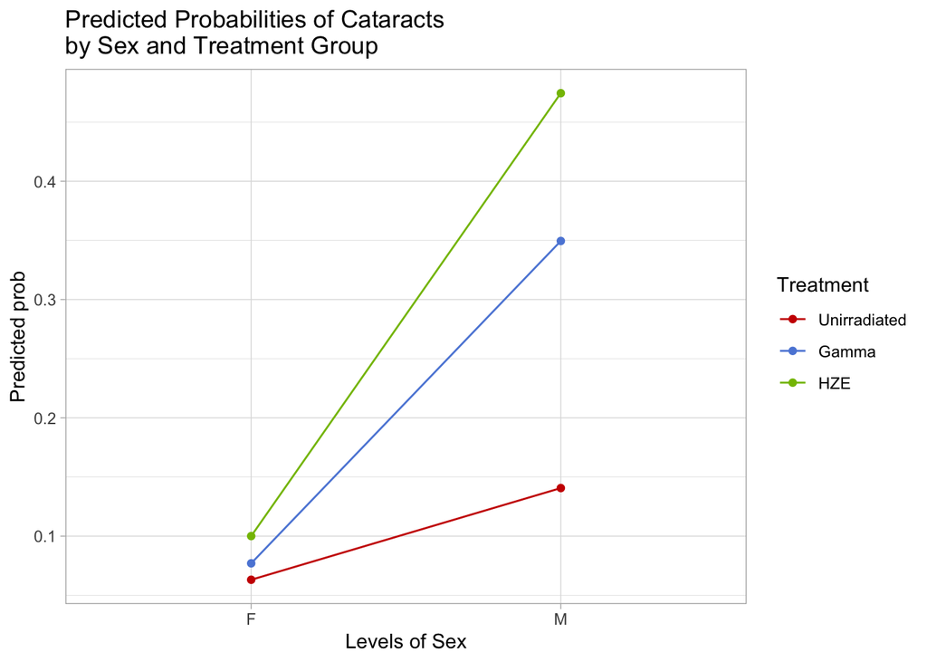

Assessing odds ratios for cataracts between groups:

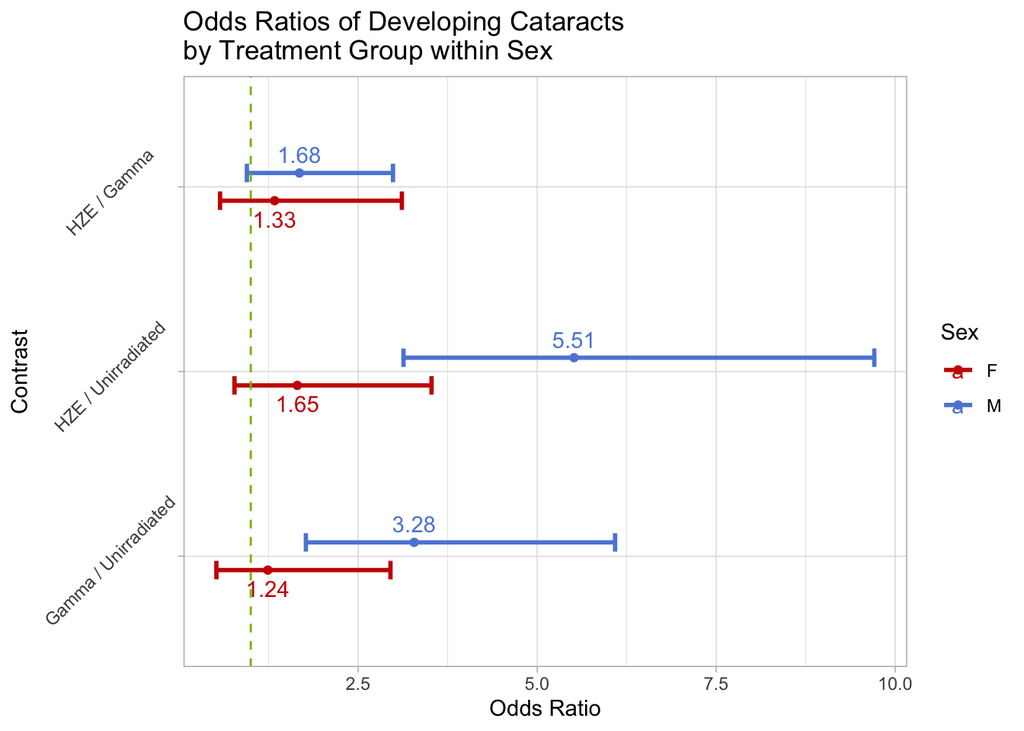

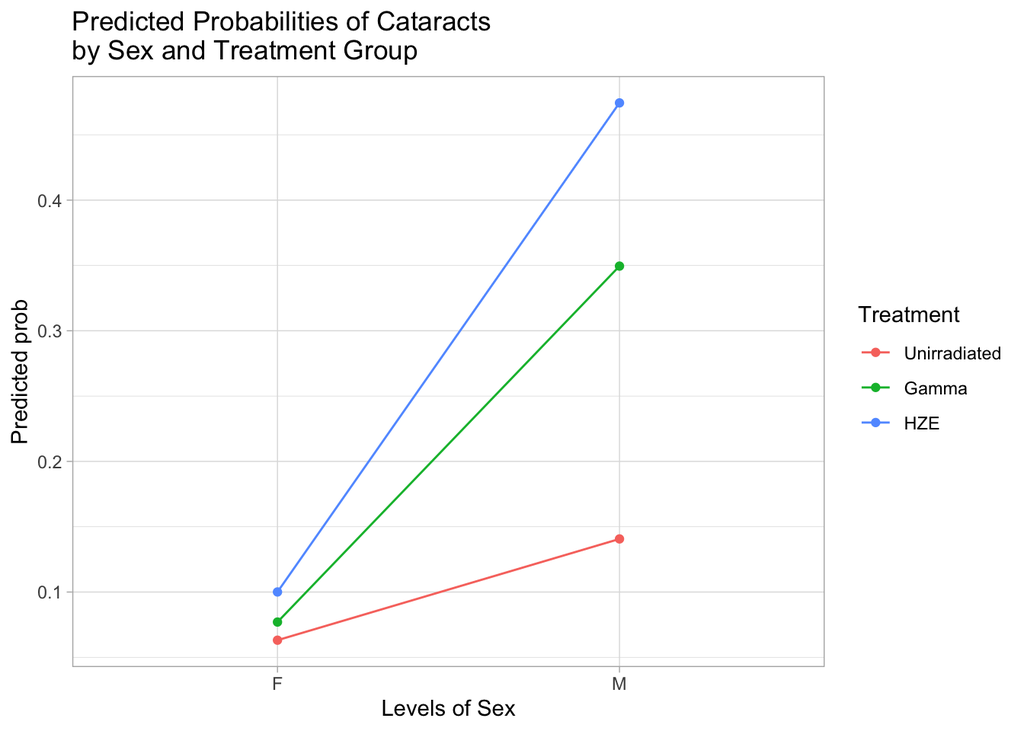

Assessing odds ratios for cataracts between groups:

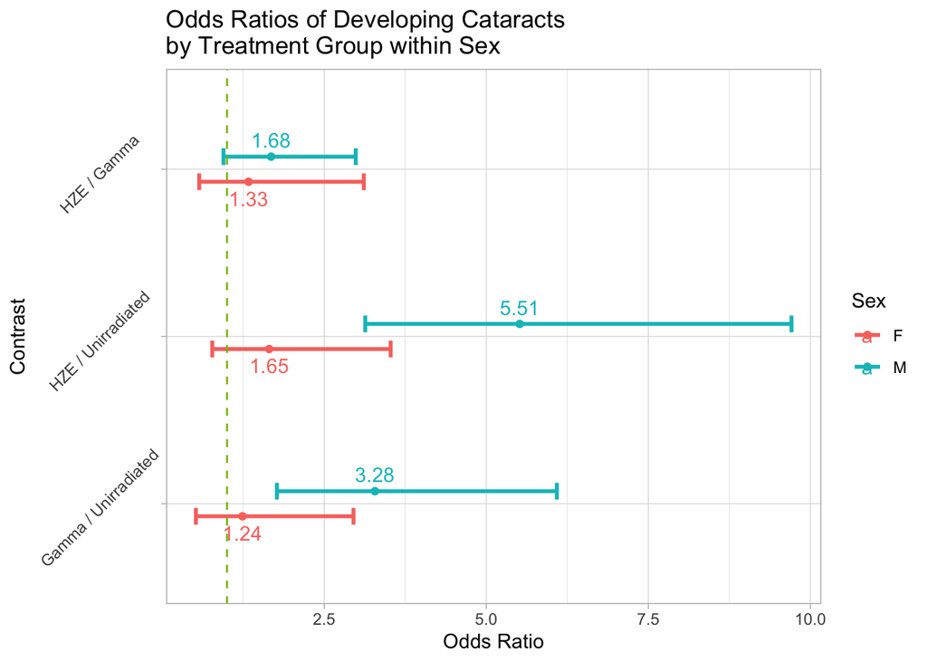

```
## Treatment = Unirradiated:
##  contrast odds.ratio    SE  df null z.ratio p.value
##  M / F          2.43 0.724 Inf    1   2.977  0.0029
##
## Treatment = Gamma:
##  contrast odds.ratio    SE  df null z.ratio p.value
##  M / F          6.44 2.231 Inf    1   5.374  <.0001
##
## Treatment = HZE:
##  contrast odds.ratio    SE  df null z.ratio p.value
##  M / F          8.12 2.220 Inf    1   7.658  <.0001
##
## Tests are performed on the log odds ratio scale
```

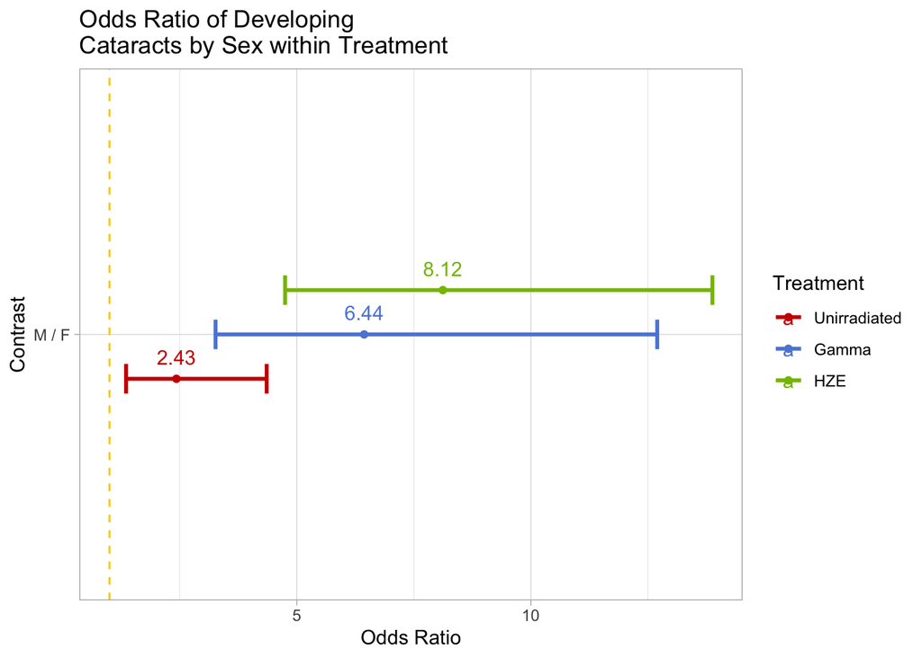

Assessing relative risk for cataracts between groups:

[figure not shown]

[figure not shown]

Visualizing random effect by family:

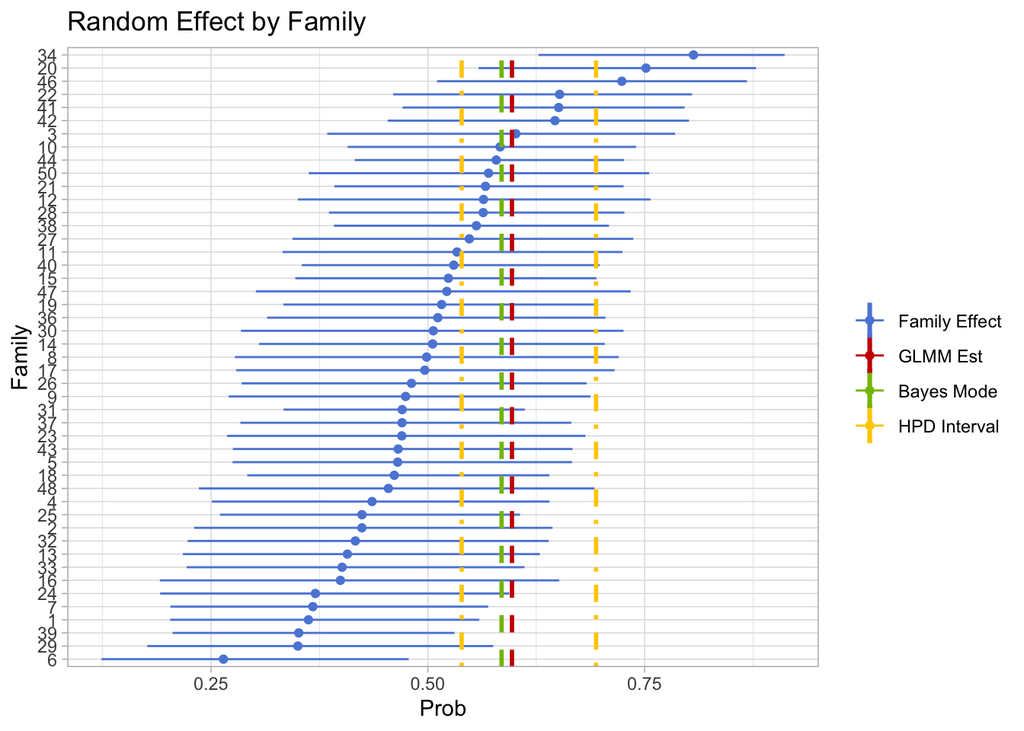

## Authors’ Statements

Both authors contributed to statistical analysis and writing for this report. Both authors read and approved the final report. Both authors contributed equally to introduction, exploratory data analysis, summary statistics, and results. Alyssa Allsop served as the primary statistician on fitting Frequentist models; Amira Burns served as the primary statistician on fitting the Bayesian model.

## References

Agresti, A (2013). *Categorical Data Analysis* (Third Edition). John Wiley & Sons.

Chernyavskiy, P., Edmondson, E. F., Weil, M. M., & Little, M. P. (2017). *High-energy particle beam and gamma radiation exposure, familial relatedness and cancer in mice.* British journal of cancer, 117(1), 41–50. https://doi.org/10.1038/bjc.2017.141

Gelman, A., Carlin, J., Stern, H., Dunson, D., Vehtari, A., Rubin, D. (2014). *Bayesian Data Analysis* (Third Edition). CRC Press.

Roback, P., Legler, J. (2021). *Beyond Multiple Linear Regression. Applied Generalized Linear Models and Multilevel Models in R* (Second Edition). CRC Press. Online version: https://bookdown.org/roback/bookdown-BeyondMLR/

DiMaggio, C., Albert, J., Spiegelhalter, D., Best, N., Gelman, A., Carstensen, B., Guerrin, L., Jensen, S. (2015) *Bayesian Analysis for Epidemiologists III: Regression Modeling.* Center for Injury Epidemiology and Prevention at Columbia University. http://www.columbia.edu/~cjd11/charles_dimaggio/DIRE/styled-4/styled-11/code-8/#bayesian-regression-modeling-with-bugs-or-jags

R Packages:  
+ Douglas Bates, Martin Maechler, Ben Bolker, Steve Walker (2015). Fitting Linear Mixed-Effects Models Using lme4. Journal of Statistical Software, 67(1), 1-48. doi:10.18637/jss.v067.i01.  
+ Martyn Plummer (2021). rjags: Bayesian Graphical Models using MCMC. R package version 4-12. https://CRAN.R-project.org/package=rjags  
+ Russell V. Lenth (2022). emmeans: Estimated Marginal Means, aka Least-Squares Means. R package version 1.7.3. https://CRAN.R-project.org/package=emmeans

## Appendix

### Bayes Model Diagnostics

[figure not shown]

Assessing relative risk for cataracts between groups:

[figure not shown]

[figure not shown]

Visualizing random effect by family:

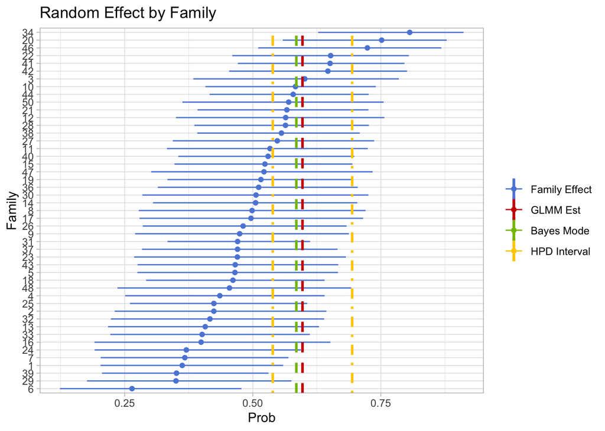

## 0.7 Authors’ Statements

Both authors contributed to statistical analysis and writing for this report. Both authors read and approved the final report. Both authors contributed equally to introduction, exploratory data analysis, summary statistics, and results. Alyssa Allsop served as the primary statistician on fitting Frequentist models; Amira Burns served as the primary statistician on fitting the Bayesian model.

## 0.8 References

Agresti, A (2013). *Categorical Data Analysis* (Third Edition). John Wiley & Sons.

Chernyavskiy, P., Edmondson, E. F., Weil, M. M., & Little, M. P. (2017). *High-energy particle beam and gamma radiation exposure, familial relatedness and cancer in mice.* British journal of cancer, 117(1), 41–50. https://doi.org/10.1038/bjc.2017.141

Gelman, A., Carlin, J., Stern, H., Dunson, D., Vehtari, A., Rubin, D. (2014). *Bayesian Data Analysis* (Third Edition). CRC Press.

Roback, P., Legler, J. (2021). *Beyond Multiple Linear Regression. Applied Generalized Linear Models and Multilevel Models in R* (Second Edition). CRC Press. Online version: https://bookdown.org/roback/bookdown-BeyondMLR/

DiMaggio, C., Albert, J., Spiegelhalter, D., Best, N., Gelman, A., Carstensen, B., Guerrin, L., Jensen, S. (2015) *Bayesian Analysis for Epidemiologists III: Regression Modeling.* Center for Injury Epidemiology and Prevention at Columbia University. http://www.columbia.edu/~cjd11/charles_dimaggio/DIRE/styled-4/styled-11/code-8/#bayesian-regression-modeling-with-bugs-or-jags

R Packages:  
+ Douglas Bates, Martin Maechler, Ben Bolker, Steve Walker (2015). Fitting Linear Mixed-Effects Models Using lme4. Journal of Statistical Software, 67(1), 1-48. doi:10.18637/jss.v067.i01.  
+ Martyn Plummer (2021). rjags: Bayesian Graphical Models using MCMC. R package version 4-12. https://CRAN.R-project.org/package=rjags  
+ Russell V. Lenth (2022). emmeans: Estimated Marginal Means, aka Least-Squares Means. R package version 1.7.3. https://CRAN.R-project.org/package=emmeans

## 0.9 Appendix

### 0.9.4 Bayes Model Diagnostics

Traceplots:

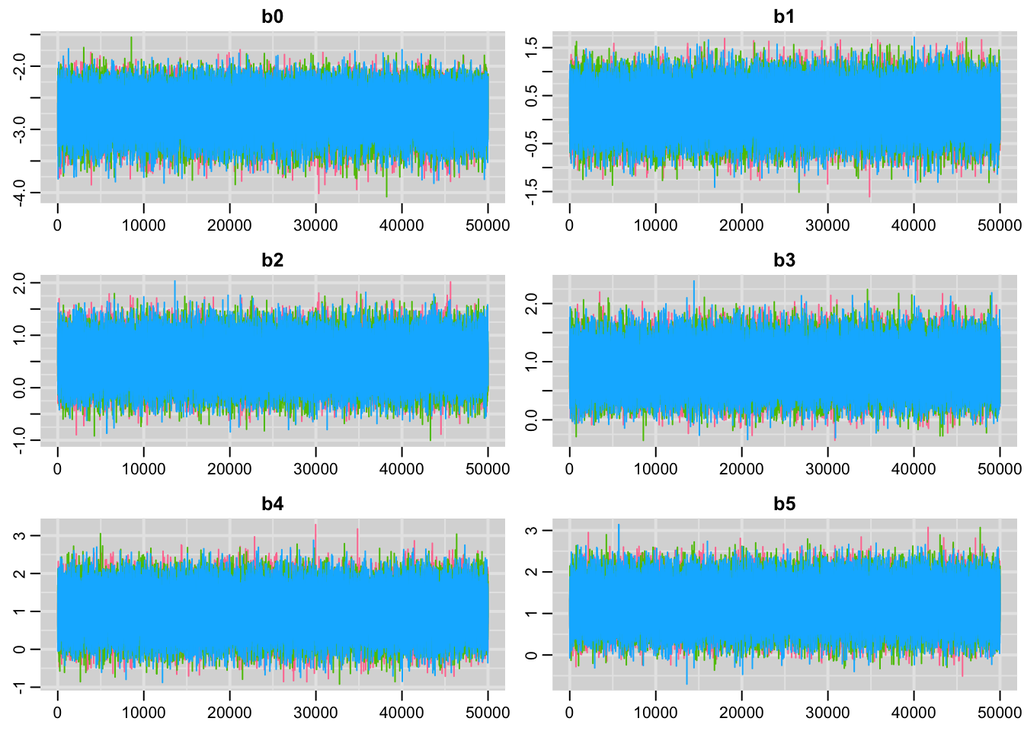

ACF plots:

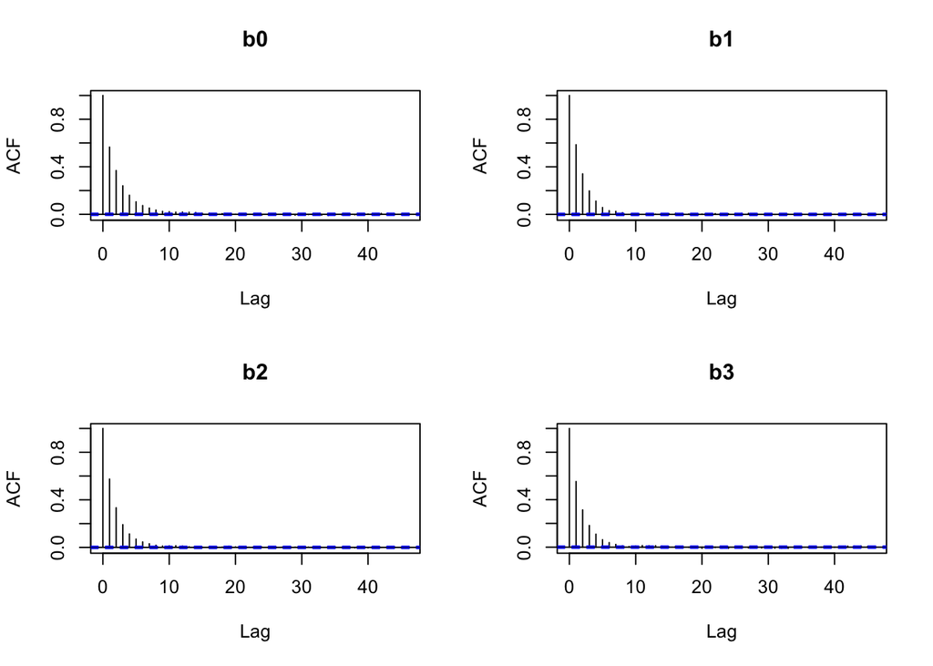

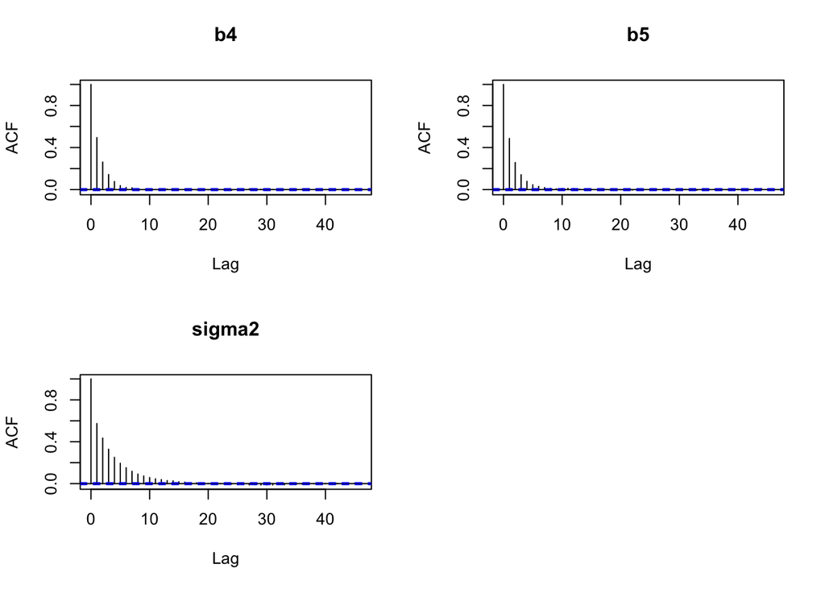

Gelman-Rubin Diagnostics:

```
## Potential scale reduction factors:
##
##          Point est. Upper C.I.
## b0                1          1
## b1                1          1
## b2                1          1
## b3                1          1
## b4                1          1
## b5                1          1
## deviance          1          1
## sigma2            1          1
##
## Multivariate psrf
##
## 1
```

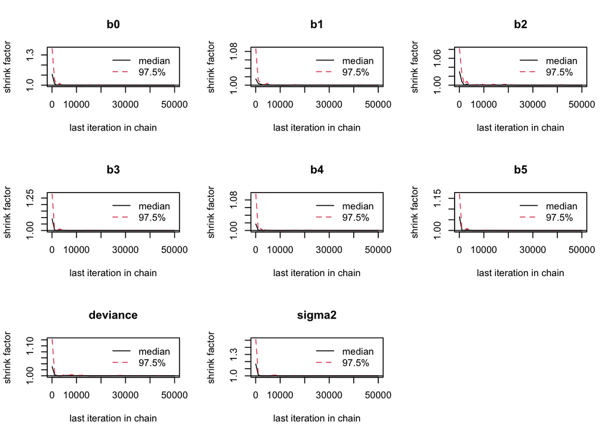

### 0.9.5 Post-Hoc Assessments

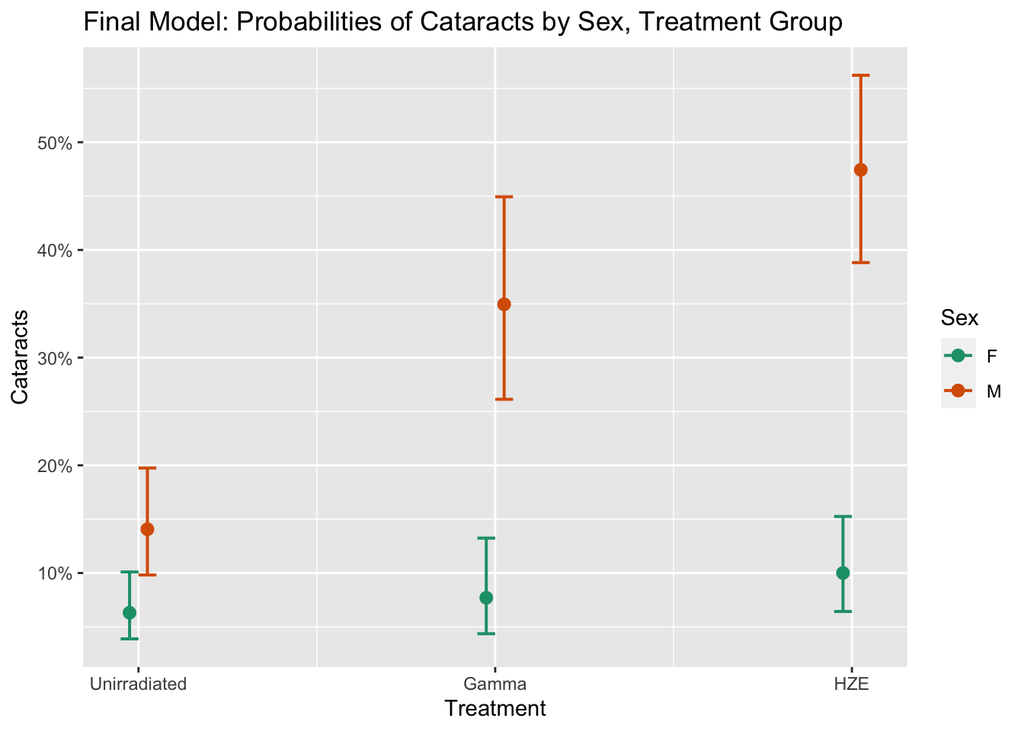

|  | Final Model: Odds Ratios of Cataracts by Sex, Treatment Group |  |  |
| --- | --- | --- | --- |
| Predictors | Odds Ratios | CI | p |
| Control(Female) | 0.07 | 0.04 – 0.11 | **<0.001** |
| Gamma(Female) | 1.24 | 0.60 – 2.56 | 0.564 |
| HZE(Female) | 1.65 | 0.87 – 3.11 | 0.122 |
| Control(Male) | 2.43 | 1.35 – 4.36 | **0.003** |
| Gamma(Male) | 2.65 | 1.09 – 6.46 | **0.032** |
| HZE(Male) | 3.34 | 1.52 – 7.35 | **0.003** |
| Random Effects |  |  |  |
| σ<sup>2</sup> | 3.29 |  |  |
| τ<sub>00</sub> <sub>Family</sub> | 0.39 |  |  |
| ICC | 0.11 |  |  |
| N <sub>Family</sub> | 47 |  |  |
| Observations | 1169 |  |  |
| Marginal R<sup>2</sup> / Conditional R<sup>2</sup> | 0.194 / 0.281 |  |  |